CS F364: Design and Analysis of Algorithms

# Minimum Spanning Trees

Lecture 15 |2026-06-09

# Minimum Spanning Tree (MST)

- Minimum Spanning Tree (MST)
- Applications of MST
- Cuts and the Cut Property
- The Cycle Property
- Union-Find Data Structure
- Correctness of Kruskal’s Algorithm
- Summary

## What is a Spanning Tree?

A **spanning tree** of a connected graph $G = (V, E)$ is a subgraph $T \subseteq G$ such that:

- **Spanning:** $T$ includes all $|V|$ vertices of $G$.
- **Tree:** $T$ is connected and acyclic.

**Key facts:** - Every spanning tree has exactly $|V|-1$ edges. - There is exactly one path between any two vertices in $T$. - A connected graph can have many different spanning trees.

## Spanning Tree — Properties

- A tree is the **minimally connected** subgraph — removing any edge disconnects it.
- A tree is the **maximally acyclic** subgraph — adding any edge creates a cycle.
- Every spanning tree of a graph on $n$ vertices has exactly $n-1$ edges — no more, no fewer.

$$\text{connected} + \text{acyclic} + |V|-1 \text{ edges} \;\Longleftrightarrow\; \text{spanning tree}$$

Any two of these three properties implies the third.

## Minimum Spanning Tree (MST)

Given a connected graph $G=(V, E)$ with real valued edge weights $c_e$, an **MST** is a spanning tree $T\subseteq E$ whose sum of edge weights is minimized.

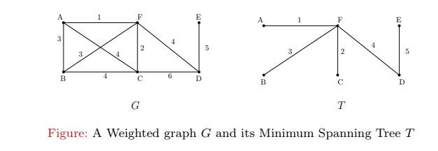

- $T$ must be a spanning tree (connected, acyclic, all $V$ vertices).
- Among all spanning trees, $T$ has the **minimum total weight**.

## Why MST?

- **Foundational problem** — one of the oldest and most well-studied in graph theory (Boruvka, 1926)
- **Greedy paradigm** — all three classical algorithms (Kruskal’s, Prim’s, Boruvka’s) are greedy
- **Building block** — used as a subroutine in approximation algorithms for harder problems (TSP, Steiner tree)
- **Applications everywhere** — networks, clustering, image analysis, error-correcting codes

# Applications of MST

- Minimum Spanning Tree (MST)
- Applications of MST
- Cuts and the Cut Property
- The Cycle Property
- Union-Find Data Structure
- Correctness of Kruskal’s Algorithm
- Summary

## Applications of MST

- **Network Design (STP)** — Ethernet switches use the Spanning Tree Protocol (IEEE 802.1D) to compute an MST of the network topology, preventing broadcast storms while maintaining connectivity.
- **Clustering** — Single-linkage clustering computes an MST of data points; removing the $k-1$ heaviest edges gives $k$ clusters. Used in phylogenetics, customer segmentation, image segmentation.
- **Approximation Algorithms** — Metric TSP uses MST for a 2-approximation; Steiner tree uses MST on terminal pairs for a 2-approximation; facility location via MST dual fitting.
- **Other uses** — LDPC error-correcting codes, medical image registration (Renyi entropy), bioinformatics (protein sequence alignment), RSTP for mesh networks.

# Cuts and the Cut Property

- Minimum Spanning Tree (MST)
- Applications of MST
- Cuts and the Cut Property
- The Cycle Property
- Union-Find Data Structure
- Correctness of Kruskal’s Algorithm
- Summary

## Graph Cut

In a graph $G=(V, E)$ a cut is a **bipartition** of $V$ into sets $S, V-S$ for some $S\subseteq V$. We show it by $(S,V-S)$.

An edge $e=\{u,v\}$ crosses the cut $(S, V-S)$ if exactly one of $u,v$ is in $S$.

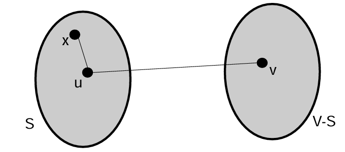

## Cut Property

Let $S$ be any subset of nodes (called a cut), and let $e = \{u, v\}$ be the minimum cost edge crossing $(S, V-S)$. Then **every MST contains $e$**.

*Proof*. **Proof.** Suppose $e$ does not belong to some MST $T^*$.

1. Adding $e$ to $T^*$ creates a cycle $C$.
2. Since $e$ crosses $(S, V-S)$, $C$ must contain some other edge $f$ that also crosses $(S, V-S)$.
3. $T = T^* \cup \{e\} - \{f\}$ is also a spanning tree.
4. Since $c_e < c_f$ (by assumption, $e$ is the cheapest crossing edge), $\text{cost}(T) < \text{cost}(T^*)$.
5. This contradicts $T^*$ being an MST. $\square$

# The Cycle Property

- Minimum Spanning Tree (MST)
- Applications of MST
- Cuts and the Cut Property
- The Cycle Property
- Union-Find Data Structure
- Correctness of Kruskal’s Algorithm
- Summary

## Cycle Property

Let $C$ be any cycle in $G$, and let $f$ be the **maximum** cost edge in $C$. Then the MST $T^*$ does **not** contain $f$.

*Proof*. **Proof.** Suppose $f$ belongs to $T^*$.

1. Deleting $f$ from $T^*$ disconnects $T^*$ into two components — let $S$ be one side of this cut.
2. Since $f \in C$, the cycle $C$ must contain some other edge $e$ that also crosses $(S, V-S)$.
3. $T = T^* \cup \{e\} - \{f\}$ is also a spanning tree.
4. Since $c_e < c_f$ (by assumption, $f$ is the most expensive in $C$), $\text{cost}(T) < \text{cost}(T^*)$.
5. This contradicts $T^*$ being an MST. $\square$

## Cut / Cycle Properties — Intuition

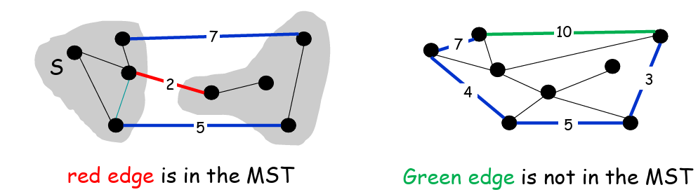

- **Cut property:** Heavy edges can’t go in, light edges can’t stay out.
- **Cycle property:** The heaviest edge in any cycle is never needed.
- Together, these two properties completely characterize the MST: an edge belongs to *some* MST iff there exists a cut for which it is lightest, and to *every* MST iff it is the unique lightest edge in some cut.

## Kruskal’s Algorithm

**Algorithm:**

1. Sort edges by weight.
2. $F \gets \emptyset$.
3. For each $(u,v)$: add if different components, else skip.

Step 0 / 9 — click ▶

[interactive chart not shown]

─ pending ─ MST ─ skip

# Union-Find Data Structure

- Minimum Spanning Tree (MST)
- Applications of MST
- Cuts and the Cut Property
- The Cycle Property
- Union-Find Data Structure
- Correctness of Kruskal’s Algorithm
- Summary

## The Problem: Cycle Detection

Kruskal’s algorithm needs to check: are $u$ and $v$ already in the same connected component?

- Naively: DFS from $u$ each time $\Rightarrow O(V)$ per check $\Rightarrow O(EV)$ total.
- We need a data structure that supports:
  - `find(u)` — which component does $u$ belong to?
  - `union(u, v)` — merge the components of $u$ and $v$.

**Union-Find** (a.k.a. Disjoint Set Union, DSU) handles both in nearly constant time.

## Union-Find: Basic Operations

- **`makeset(x)`:** Create a new set containing just $x$.
  - Each element initially points to itself as its set’s representative.
- **`find(x)`:** Return the representative of the set containing $x$.
  - Follow parent pointers until reaching the root.
- **`union(x, y)`:** Merge the sets containing $x$ and $y$.
  - If $\text{find}(x) \neq \text{find}(y)$, make one root point to the other.

| Operation | Without optimization | With optimizations |
| --- | --- | --- |
| `makeset` | $O(1)$ | $O(1)$ |
| `find` | $O(\text{depth})$ | $O(\alpha(n))$ |
| `union` | $O(\text{depth})$ | $O(\alpha(n))$ |

## Union-Find: Union by Rank

**Problem:** Naively linking roots can create a chain (depth $O(n)$, making `find` slow).

**Solution (Union by Rank):** Keep track of the height (rank) of each tree. Always attach the shorter tree under the taller one.

```
union(x, y):
    rx = find(x), ry = find(y)
    if rx == ry: return
    if rank[rx] < rank[ry]: swap(rx, ry)
    parent[ry] = rx
    if rank[rx] == rank[ry]: rank[rx] += 1
```

- **Result:** Tree depth is $O(\log n)$ — good, but we can do better.

## Union-Find: Path Compression

**Idea:** During `find(x)`, after finding the root, make every node on the path point directly to the root.

```
find(x):
    if parent[x] != x:
        parent[x] = find(parent[x])
    return parent[x]
```

- **Effect:** Future `find` calls on the same chain are $O(1)$.
- **Amortized analysis:** Any sequence of $m$ operations on $n$ elements runs in $O(m\, \alpha(n))$ time, where $\alpha(n)$ is the inverse Ackermann function.
  - $\alpha(n) \le 4$ for all $n \le 2^{2^{2^{2^{16}}}}$ (essentially constant).

## Kruskal’s with Union-Find

```
KruskalMST(G, w):
    for each vertex v in V:            # makeset × |V|
        makeset(v)

    sort edges E by weight w           # O(E log E)

    F = ∅
    for each edge (u, v) in E:         # O(E α(V))
        if find(u) ≠ find(v):
            union(u, v)
            F = F ∪ {(u, v)}
            if |F| == |V| - 1: break

    return F
```

**Time complexity:**

- Sorting: $O(E \log E) = O(E \log V)$
- $V$ `makeset` $+ 2E$ `find` $+ (V-1)$ `union`: $O((E+V)\,\alpha(V)) = O(E\,\alpha(V))$
- **Total:** $O(E \log V)$ — dominated by sorting.

# Correctness of Kruskal’s Algorithm

- Minimum Spanning Tree (MST)
- Applications of MST
- Cuts and the Cut Property
- The Cycle Property
- Union-Find Data Structure
- Correctness of Kruskal’s Algorithm
- Summary

## Correctness — Overview

Kruskal’s algorithm correctly computes an MST.

We prove this by a **greedy exchange argument**:

1. Let $F$ be the set of edges built by Kruskal’s so far.
2. **Invariant:** $F$ is always a subset of some MST $M$.
3. The invariant holds initially ($F = \emptyset$).
4. When we add $e$ to $F$, we show there exists an MST $M'$ containing $F \cup \{e\}$.

## Correctness — Exchange Step

**Case 1:** $e \in M$. Trivial — set $M' = M$, invariant preserved.

**Case 2:** $e \notin M$. Then $M \cup \{e\}$ contains a cycle $C$.

- Kruskal’s added $e$, so the endpoints of $e$ were in different components of $F$.
- Following $C$ around $M$, there must be some other edge $e' \in C$ whose endpoints are also in different components of $F$.
- Since Kruskal’s chose $e$ over $e'$, we have $w(e) \le w(e')$.

Construct $M' = M \cup \{e\} - \{e'\}$:

- $M'$ is a spanning tree (same size, still connected).
- $\text{cost}(M') = \text{cost}(M) + w(e) - w(e') \le \text{cost}(M)$.
- Since $M$ is an MST, $M'$ is also an MST.
- And $F \cup \{e\} \subseteq M'$. $\square$

## Correctness — Key Insight

The **exchange argument** is the heart of greedy correctness proofs:

1. Compare your solution to any optimal solution.
2. Find the first point where they differ.
3. Swap the greedy edge into the optimal solution without making it worse.
4. Repeat — the greedy solution is also optimal.

We will see this pattern again in Prim’s algorithm, Huffman codes, and Matroids.

# Summary

- Minimum Spanning Tree (MST)
- Applications of MST
- Cuts and the Cut Property
- The Cycle Property
- Union-Find Data Structure
- Correctness of Kruskal’s Algorithm
- Summary

## What We Learned Today

- **MST definition** — minimum-weight spanning tree in a graph
- **Cut and Cycle properties** — fundamental characterizations of MST edges
- **Kruskal’s algorithm** — repeatedly add the cheapest non-cycle-creating edge
- **Union-Find** — efficient cycle detection via DSU with path compression and union by rank
- **Correctness proof** — greedy exchange argument

| Technique | Time complexity |
| --- | --- |
| Kruskal’s + Union-Find | $O(E \log V)$ |
| Kruskal’s + Union-Find (edges pre-sorted) | $O(E\,\alpha(V))$ |